# Paleobuddy overview

## paleobuddy’s flexibility

While showing use cases of the package is great, we should also spend some time detailing the possible customization options in `bd.sim` and `sample.clade`.

We have already shown speciation and extinction rates can be any function of time, or constant numbers. Let us check some other possibilities out.

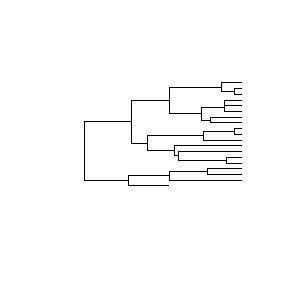

```r
# set a seed
set.seed(4)

# parameters to set things up
n0 <- 1
tMax <- 20

# speciation can be dependent on an environmental variable as well as time
pp <- function(t, env) {
  0.01 * t + 0.1*exp(0.1*env)
}

# let us generate some fake environmental data - you can pretend this is
# percentage of max temperature or something
Env <- data.frame(1:20, runif(20))
# the package RPANDA supplies some useful environmental data frames - see ?bd.sim and ?bd.sim general for
# examples with real data

# we can make extinction be age-dependent by creating a shape parameter
qq <- 10
qShape <- 2
# this will make it so species durations are distributed as a Weibull with scale 10 and shape 2

# run the simulation
# we pass the shape and environmental parameters
sim <- bd.sim(n0, pp, qq, tMax, qShape = qShape, envPP = Env)
# note that pShape and envQQ also exist
# the defaults for all of these customization options is NULL

# check out the phylogeny
ape::plot.phylo(make.phylo(sim), show.tip.label = FALSE)
```

So as to avoid repetition, we will not run simulations for the next possibilities, but we will list them

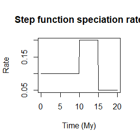

```r
# speciation may be a step function, presented as a rates vector and a shift times vector
pList <- c(0.1, 0.2, 0.05)
pShifts <- c(0, 10, 15)
# pShifts could also be c(tMax, tMax - 10, tMax - 15) for identical results

# make.rate is the function bd.sim calls to create a rate, but we will use it here to see how it looks
pp <- make.rate(pList, tMax = 20, fShifts = pShifts)
t <- seq(0, 20, 0.1)
plot(t, pp(t), type = 'l', main = "Step function speciation rate",
     xlab = "Time (My)", ylab = "Rate")
```

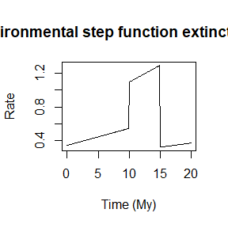

```r
# it is not possible to combine the pp(t, env) and pList methods listed above
# but we can create a step function dependent on environmental data with ifelse
q <- function(t, env) {
  ifelse(t < 10, env,
         ifelse(t < 15, env * 2, env / 2))
}

# pass it to make.rate with environmental data
qq <- make.rate(q, envF = Env)
plot(t, qq(t), type = 'l', main = "Environmental step function extinction rate",
     xlab = "Time (My)", ylab = "Rate")
```

Note all these customization options could serve for a weibull scale as well, if the user wishes to have age-dependent speciation and/or extinction. The possibility of age-dependency with time-varying rates is, to our knowledge, exclusive to `paleobuddy`.

```r
# set seed again
set.seed(1)

# age-dependent speciation with a step function
pList <- c(10, 5, 12)
pShifts <- c(0, 10, 15)
pShape <- 0.5

# age-dependent extinction with a step function of an environmental variable
q <- function(t, env) {
  ifelse(t < 10, 20*env,
         ifelse(t < 15, 10*env, 13*env / 2))
}
qShape <- 2

# run the simulation
sim <- bd.sim(n0, pList, q, tMax, pShape = 0.5, qShape = 2, envQQ = Env, pShifts = pShifts)
```

We set this to not run because it takes a long time - both because of the high speciation and because the method of creating a step function rate with `shifts` and `lists` takes a long time to integrate. It is however a good illustration of the power of `paleobuddy`s flexibility.

Note shape may also be a time-varying function, but that was not thoroughly tested and therefore not a recommended feature at the moment.

None of the scenarios we have listed here are specific to speciation or extinction - one can mix and match any combination listed here for either rate.

In the case of sampling rates, it is almost the case that any scenario available to speciation/extinction is available to sampling. We do not allow for a `shape` parameter since the Weibull distribution is not frequently used in the literature for age-dependent sampling. Instead, we allow for the user to supply a probability distribution signifying how occurrences are distributed along a species age, as follows

```r
# as an example, we will use a PERT distribution, a hat-shaped distribution used in PyRate
# preservation function
dPERT <- function(t, s, e, sp, a = 3, b = 3, log = FALSE) {

  # check if it is a valid PERT
  if (e >= s) {
    message("There is no PERT with e >= s")
    return(rep(NaN, times = length(t)))
  }

  # find the valid and invalid times
  id1 <- which(t <= e | t >= s)
  id2 <- which(!(t <= e | t >= s))
  t <- t[id2]

  # initialize result vector
  res <- vector()

  # if user wants a log function
  if (log) {
    # invalid times get -Inf
    res[id1] <- -Inf

    # valid times calculated with log
    res[id2] <- log(((s - t) ^ 2)*((-e + t) ^ 2)/((s - e) ^ 5*beta(a,b)))
  }
  # otherwise
  else{
    res[id1] <- 0

    res[id2] <- ((s - t) ^ 2)*((-e + t) ^ 2)/((s - e) ^ 5*beta(a,b))
  }

  return(res)
}

# function to calculate max of the PERT - makes the sampling faster
dPERTmax <- function(s, e, sp) {
  return(((s - e) / 2) + e)
}

# set seed
set.seed(1)

# generate a quick simulation
sim <- bd.sim(n0, pp = 0.1, qq = 0.05, tMax = 20)

# another seed
set.seed(1)

# sample - high sampling rate so we can visualize the age-dependency
samp <- sample.clade(sim = sim, rr = 30, tMax = 20, bins = bins,
                  dFun = dPERT, dFunMax = dPERTmax)
```

```
## 0 species left no fossil
```

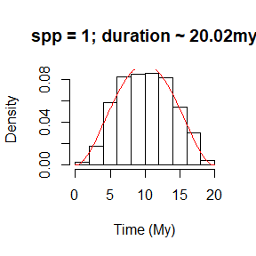

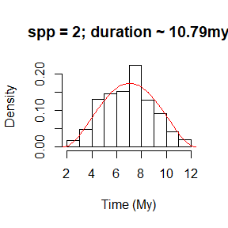

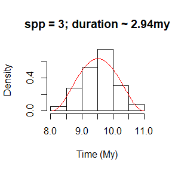

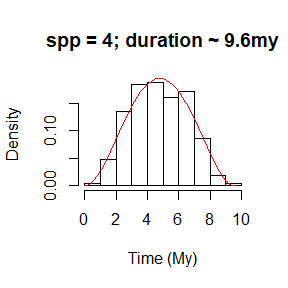

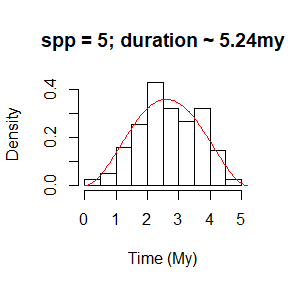

```r
# extract species identity
ids <- unique(samp$Species)

# approximate sampling time (since it is a range)
mids <- (samp$MaxT - samp$MinT) / 2 + samp$MinT

# for each species
for (i in 1:length(ids)) {
  # get the species number
  sp <- unique(as.numeric(gsub("spp_", "", ids[i])))

  # check the histogram
  hist(mids[samp$Species == ids[[i]]],
       main = paste0("spp = ", sp, "; duration ~ ",
                     round(sim$TS[sp] - sim$TE[sp], digits = 2), "my"),
       xlab = "Time (My)", probability = TRUE)

  # expected curve
  curve(dPERT(x, s = sim$TS[sp], e = sim$TE[sp], sp = sp), from = sim$TE[sp],
        to = sim$TS[sp], add = TRUE, col = "red", n = 100)
}
```

For more details and examples of age-dependent models, check out `?sample.adpp` and `?sample.clade`. When a `dFun` argument is supplied for age dependency, the average sampling rate `rr` must be a constant. We omit examples of non-age-dependent sampling rate options since they are just the same options as birth-death rates, excluding shape parameters.

## Conclusion

For completion, we present a final list of the functions of the package

- `bd.sim` birth-death simulator. Rates can be constant, time dependent, time and enviromentally dependent, or a list of numbers. User can supply a shape parameter to make rate a Weibull scale.
- `bd.sim.constant` function called by `bd.sim` when rates are constant.
- `bd.sim.general` function called by `bd.sim` when they are not.
- `make.phylo` creates a `phylo` object from the `ape` package.
- `sample.clade` samples a whole group, usually outputted from `bd.sim`. Sampling rate can be anything a speciation or extinction rate can be, without the option of a shape parameter. If sampling is constant, the user may also supply a distribution of age-dependent occurrences.
- `sample.species` function called by `sample.clade` when sampling is not age-dependent
- `sample.adpp` function called by `sample.clade` when sampling is age-dependent (i.e. Age Dependent Poisson Process)
- `rexp.var` exponential and weibull waiting time drawing with variable rates. Used by `bd.sim` and `sample.clade`.
- `find.lineages` separates a group returned by the `bd.sim` function, or similar, by the species that started the simulation as mothers of each group. Allows for an optional argument, a list of numbers, and if supplied returns the groups generated by those species instead. A quick example:

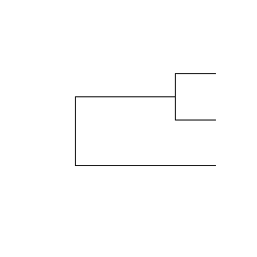

```r
# simple simulation, starting with more than one species
sim <- bd.sim(n0 = 2, pp = 0.1, qq = 0, tMax = 20, nFinal = c(20, Inf))

# separate the lineages
clades <- find.lineages(sim)

# plot each phylogeny

# clade 1
ape::plot.phylo(make.phylo(clades$clade_1), show.tip.label = FALSE)
```

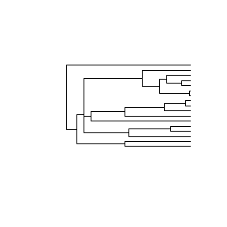

```r
# clade 2
ape::plot.phylo(make.phylo(clades$clade_2), show.tip.label = FALSE)
```

- `make.rate` creates a function of time from the customization options presented above - vector of numbers and vector of shif times, function of time and environment and an environment matrix, etc. Used by `bd.sim` and `sample.clade` to detect when the given rates are constant, and create the rates to pass to the helper functions.
- `var.rate.div` calculates the expected diversity from a variable rate birth-death process and a time period.
- `binner` given occurrence times and time bins, returns the number of occurrences in each bin.

While the package is robust and flexible, it is useful to spend a little time discussing the shortcomings and planned features.

- Currently, time-varying shape is an untested feature of the package. This is a glaring omission given that time-varying scale is well tested, and we plan on devising better testing methods so we can effectively present this as a feature.
- The method of generating step functions from rate and shift times vectors is currently very slow (see `?make.rate`), and we plan on looking for more efficient alternatives. Meanwhile, the user might prefer the creation of step functions using `ifelse` when prioritizing efficiency.
- A couple of diversification scenarios are very well established in the literature and therefore are planned for future versions of the package: trait-dependent diversification, diversity-dependent rates, anagenesis/bifurcating speciation, etc.